# ResearchProject-Anu-2

## Objectives

The main objective of this project is to analyze the following three questions :

1. Which genres receive the highest ratings? How does this change over time?
2. Build model to predict ratings for future unseen data (test data).
3. Which factor affects the popularity of movie? Is it the budget or the length of movie?

## Loading Libraries

```r
library(caret)
library(tidyverse)
library(lubridate)
install.packages('wordcloud')
library(wordcloud)
library(stringr)
library(tidytext)
library(wordcloud)
set.seed(1234)
library(modelr)
library(randomForest)
library(plotROC)
library(psych)
```

## Loading Data

The dataset is previously split into four csv files namely movies.csv, ratings.csv, tags.csv, links.csv. These files are iteratively loaded using read_csv() function and summary() function to show the summary statistics of each csv files.

```r
movies = read_csv('data/ml-20m/movies.csv')
summary(movies)
```

```
    movieId          title              genres
 Min.   :     1   Length:27278       Length:27278
 1st Qu.:  6931   Class :character   Class :character
 Median : 68068   Mode  :character   Mode  :character
 Mean   : 59855
 3rd Qu.:100293
 Max.   :131262
```

```r
tags = read_csv('data/ml-20m/tags.csv')
summary(tags)
```

```
     userId          movieId           tag              timestamp
 Min.   :    18   Min.   :     1   Length:465564      Min.   :1.135e+09
 1st Qu.: 28780   1st Qu.:  2571   Class :character   1st Qu.:1.245e+09
 Median : 70201   Median :  7373   Mode  :character   Median :1.302e+09
 Mean   : 68712   Mean   : 32628                      Mean   :1.299e+09
 3rd Qu.:107322   3rd Qu.: 62235                      3rd Qu.:1.366e+09
 Max.   :138472   Max.   :131258                      Max.   :1.428e+09
```

```r
ratings = read_csv('data/ml-20m/ratings.csv')
summary(ratings)
```

```
     userId          movieId           rating        timestamp
 Min.   :     1   Min.   :     1   Min.   :0.500   Min.   :7.897e+08
 1st Qu.: 34395   1st Qu.:   902   1st Qu.:3.000   1st Qu.:9.668e+08
 Median : 69141   Median :  2167   Median :3.500   Median :1.104e+09
 Mean   : 69046   Mean   :  9042   Mean   :3.526   Mean   :1.101e+09
 3rd Qu.:103637   3rd Qu.:  4770   3rd Qu.:4.000   3rd Qu.:1.226e+09
 Max.   :138493   Max.   :131262   Max.   :5.000   Max.   :1.428e+09
```

```r
links = read_csv('data/ml-20m/links.csv')
summary(links)
```

```
    movieId          imdbId              tmdbId
 Min.   :     1   Length:27278       Min.   :     2
 1st Qu.:  6931   Class :character   1st Qu.: 15936
 Median : 68068   Mode  :character   Median : 39468
 Mean   : 59855                      Mean   : 63847
 3rd Qu.:100293                      3rd Qu.: 82504
 Max.   :131262                      Max.   :421510
                                     NA's   :252
```

```r
tmdb = read_csv('data/tmdb_5000_movies.csv')
summary(tmdb)
```

[output not shown]

```
     budget             genres            homepage               id
 Min.   :        0   Length:4803        Length:4803        Min.   :     5
 1st Qu.:   790000   Class :character   Class :character   1st Qu.:  9014
 Median : 15000000   Mode  :character   Mode  :character   Median : 14629
 Mean   : 29045040                                         Mean   : 57166
 3rd Qu.: 40000000                                         3rd Qu.: 58610
 Max.   :380000000                                         Max.   :459488

   keywords         original_language  original_title       overview
 Length:4803        Length:4803        Length:4803        Length:4803
 Class :character   Class :character   Class :character   Class :character
 Mode  :character   Mode  :character   Mode  :character   Mode  :character




   popularity      production_companies production_countries
 Min.   :  0.000   Length:4803          Length:4803
 1st Qu.:  4.668   Class :character     Class :character
 Median : 12.922   Mode  :character     Mode  :character
 Mean   : 21.492
 3rd Qu.: 28.314
 Max.   :875.581

  release_date           revenue             runtime    spoken_languages
 Min.   :1916-09-04   Min.   :0.000e+00   Min.   :  0   Length:4803
 1st Qu.:1999-07-14   1st Qu.:0.000e+00   1st Qu.: 94   Class :character
 Median :2005-10-03   Median :1.917e+07   Median :104   Mode  :character
 Mean   :2002-12-27   Mean   :8.226e+07   Mean   :107
 3rd Qu.:2011-02-16   3rd Qu.:9.292e+07   3rd Qu.:118
 Max.   :2017-02-03   Max.   :2.788e+09   Max.   :338
 NA's   :1                                NA's   :80
    status            tagline             title            vote_average
 Length:4803        Length:4803        Length:4803        Min.   : 0.000
 Class :character   Class :character   Class :character   1st Qu.: 5.600
 Mode  :character   Mode  :character   Mode  :character   Median : 6.200
                                                          Mean   : 6.092
                                                          3rd Qu.: 6.800
                                                          Max.   :10.000

   vote_count
 Min.   :    0.0
 1st Qu.:   54.0
 Median :  235.0
 Mean   :  690.2
 3rd Qu.:  737.0
 Max.   :13752.0
```

```r
nrow(tmdb)
```

4803

## Cleaning DataSet

### Let's clean the ratings dataset

```r
head(ratings)
```

| userId | movieId | rating | timestamp |
| --- | --- | --- | --- |
| 1 | 2 | 3.5 | 1112486027 |
| 1 | 29 | 3.5 | 1112484676 |
| 1 | 32 | 3.5 | 1112484819 |
| 1 | 47 | 3.5 | 1112484727 |
| 1 | 50 | 3.5 | 1112484580 |
| 1 | 112 | 3.5 | 1094785740 |

Only the column timestamp needs to be cleaned. Let's convert it into the proper format as follows :

```r
ratings_dataf <- ratings %>%
  mutate(timestamp = as_datetime(timestamp))
```

```r
head(ratings_dataf)
```

| userId | movieId | rating | timestamp |
| --- | --- | --- | --- |
| 1 | 2 | 3.5 | 2005-04-02 23:53:47 |
| 1 | 29 | 3.5 | 2005-04-02 23:31:16 |
| 1 | 32 | 3.5 | 2005-04-02 23:33:39 |
| 1 | 47 | 3.5 | 2005-04-02 23:32:07 |
| 1 | 50 | 3.5 | 2005-04-02 23:29:40 |
| 1 | 112 | 3.5 | 2004-09-10 03:09:00 |

### Let's clean the tags dataset

```r
head(tags)
```

| userId | movieId | tag | timestamp |
| --- | --- | --- | --- |
| 18 | 4141 | Mark Waters | 1240597180 |
| 65 | 208 | dark hero | 1368150078 |
| 65 | 353 | dark hero | 1368150079 |
| 65 | 521 | noir thriller | 1368149983 |
| 65 | 592 | dark hero | 1368150078 |
| 65 | 668 | bollywood | 1368149876 |

Only the column timestamp needs to be cleaned. Let's convert it into the proper format as follows :

```r
tags_dataf <- tags %>%
  mutate(timestamp = as_datetime(timestamp))
```

```r
head(tags_dataf)
```

| userId | movieId | tag | timestamp |
| --- | --- | --- | --- |
| 18 | 4141 | Mark Waters | 2009-04-24 18:19:40 |
| 65 | 208 | dark hero | 2013-05-10 01:41:18 |
| 65 | 353 | dark hero | 2013-05-10 01:41:19 |
| 65 | 521 | noir thriller | 2013-05-10 01:39:43 |
| 65 | 592 | dark hero | 2013-05-10 01:41:18 |
| 65 | 668 | bollywood | 2013-05-10 01:37:56 |

## Converting dataset

```r
head(movies)
```

| movieId | title | genres |
| --- | --- | --- |
| 1 | Toy Story (1995) | Adventure\|Animation\|Children\|Comedy\|Fantasy |
| 2 | Jumanji (1995) | Adventure\|Children\|Fantasy |
| 3 | Grumpier Old Men (1995) | Comedy\|Romance |
| 4 | Waiting to Exhale (1995) | Comedy\|Drama\|Romance |
| 5 | Father of the Bride Part II (1995) | Comedy |
| 6 | Heat (1995) | Action\|Crime\|Thriller |

There are multiple genres in single line separated by |. We need to convert it such that each genres occur in a separate rows. Let's do this as follows.

```r
movies_dataf = movies %>%
  separate_rows(genres, sep = "\\|")
```

```r
head(movies_dataf)
```

| movieId | title | genres |
| --- | --- | --- |
| 1 | Toy Story (1995) | Adventure |
| 1 | Toy Story (1995) | Animation |
| 1 | Toy Story (1995) | Children |
| 1 | Toy Story (1995) | Comedy |
| 1 | Toy Story (1995) | Fantasy |
| 2 | Jumanji (1995) | Adventure |

## Exploring the Dataset

### Let's observe the most popular genres using the wordCloud

```r
genres_dataf <- movies_dataf %>%
  group_by(genres) %>%
  summarise(count = n()) %>%
  arrange(desc(count))
```

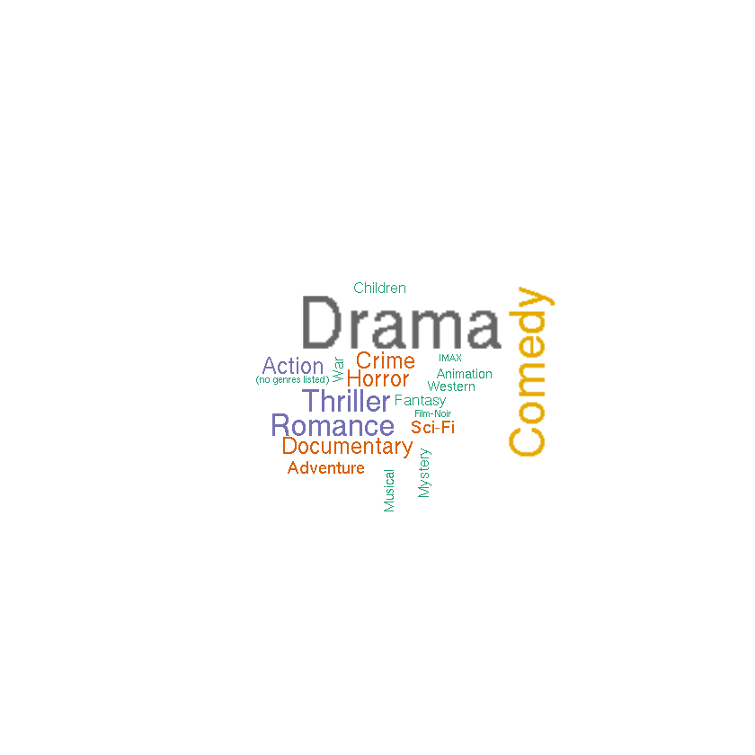

```r
wordcloud(genres_dataf$genres, genres_dataf$count, colors=brewer.pal(8, "Dark2"))
```

### Let's see the distribution of ratings

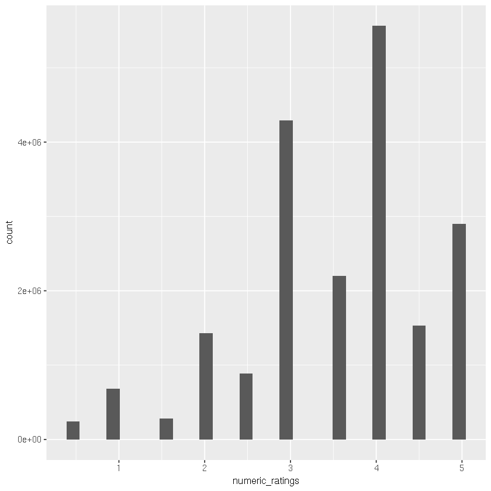

```r
ratings_dataf$numeric_ratings = as.numeric(ratings_dataf$rating)
ggplot(ratings_dataf) +
aes(x=numeric_ratings)+
geom_histogram()
```

### Let's see the average movie ratings for each movie genre

```r
movie_genre = ratings_dataf %>%
inner_join(movies_dataf) %>%
na.omit()
```

```r
movie_genre_ratings = movie_genre %>%
group_by(genres) %>%
summarize(MeanRating = mean(rating)) %>%
filter(genres !="(no genres listed)")
```

```r
unique(movie_genre_ratings$genres)
```

1. 'Action'

2. 'Adventure'

3. 'Animation'

4. 'Children'

5. 'Comedy'

6. 'Crime'

7. 'Documentary'

8. 'Drama'

9. 'Fantasy'

10. 'Film-Noir'

11. 'Horror'

12. 'IMAX'

13. 'Musical'

14. 'Mystery'

15. 'Romance'

16. 'Sci-Fi'

17. 'Thriller'

18. 'War'

19. 'Western'

```r
head(movie_genre_ratings)
```

| genres | MeanRating |
| --- | --- |
| Action | 3.443864 |
| Adventure | 3.501893 |
| Animation | 3.617494 |
| Children | 3.408114 |
| Comedy | 3.426011 |
| Crime | 3.674528 |

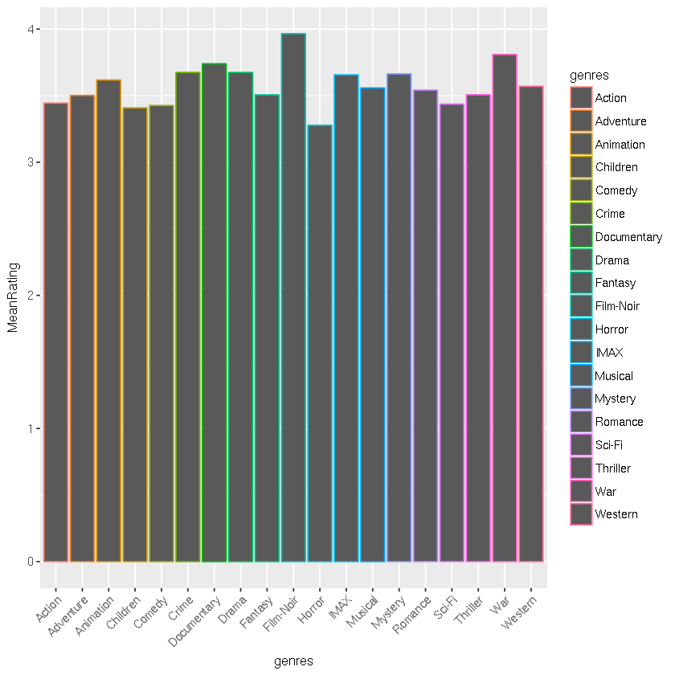

```r
ggplot(movie_genre_ratings) +
aes(x=genres, y=MeanRating, color=genres)+
theme(axis.text.x=element_text(angle=45,hjust=1))+
geom_bar(stat='identity')
```

## Evaluation

### Which genres receive the highest ratings? How does this change over time?

```r
movie_genre_ratings %>% arrange(desc(MeanRating)) %>% head(1)
```

| genres | MeanRating |
| --- | --- |
| Film-Noir | 3.965381 |

Film-Noir genre received the highest rating

```r
head(movie_genre)
```

| userId | movieId | rating | timestamp | numeric_ratings | title | genres |
| --- | --- | --- | --- | --- | --- | --- |
| 1 | 2 | 3.5 | 2005-04-02 23:53:47 | 3.5 | Jumanji (1995) | Adventure |
| 1 | 2 | 3.5 | 2005-04-02 23:53:47 | 3.5 | Jumanji (1995) | Children |
| 1 | 2 | 3.5 | 2005-04-02 23:53:47 | 3.5 | Jumanji (1995) | Fantasy |
| 1 | 29 | 3.5 | 2005-04-02 23:31:16 | 3.5 | City of Lost Children, The (Cité des enfants perdus, La) (1995) | Adventure |
| 1 | 29 | 3.5 | 2005-04-02 23:31:16 | 3.5 | City of Lost Children, The (Cité des enfants perdus, La) (1995) | Drama |
| 1 | 29 | 3.5 | 2005-04-02 23:31:16 | 3.5 | City of Lost Children, The (Cité des enfants perdus, La) (1995) | Fantasy |

Let's convert the timestamp to date format

```r
movie_genre$timestamp=as.Date(movie_genre$timestamp,format="%Y")
```

```r
class(movie_genre$timestamp)
```

'Date'

```r
movie_genre_lag = movie_genre %>%
                    group_by(genres) %>%
                    arrange(timestamp) %>%
                    mutate(lags = (lag(numeric_ratings)))
# Replace NA with zero
movie_genre_lag[is.na(movie_genre_lag)] <- 0
```

```r
#Find the average yearly change for each genre and calculate the avgChange using the lag function
movie_genre_change = movie_genre_lag %>%
                    group_by(genres,timestamp) %>%
                    summarize(avgChange = mean(lags))
```

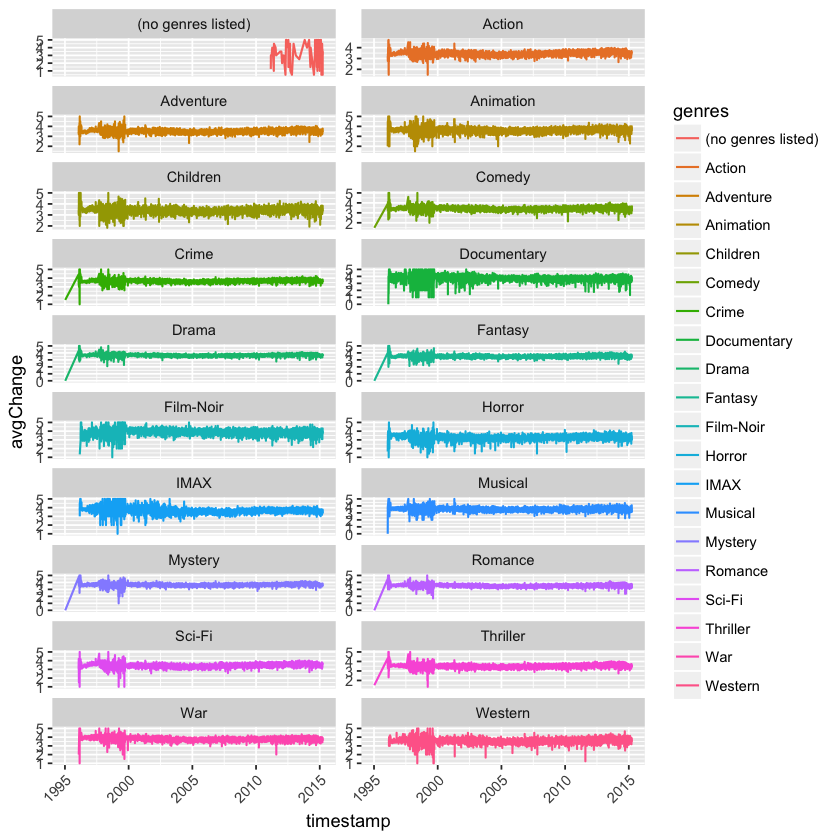

```r
# Plot the change in ratings per genre per year
movie_genre_change%>%  ggplot(aes(x=timestamp, y=avgChange, color = genres)) +
                       geom_line(size = 0.6, alpha = 1) +
                       theme(axis.text.x=element_text(angle=45,hjust=1))+
                       facet_wrap(~genres, ncol=2, scales='free_y')
```

### Join the tmdb dataset with link dataset

```r
nrow(links)
```

27278

```r
tmdb_dataf = links %>%
            left_join(tmdb, by=c("tmdbId" = "id")) %>%
            select(-keywords,-production_countries,-spoken_languages,-status,-production_companies,-genres,-original_title,-title,-overview,-homepage)
```

```r
nrow(tmdb_dataf)
```

27278

```r
tmdb_dataf = tmdb_dataf %>% na.omit()
```

```r
nrow(tmdb_dataf)
```

3573

```r
head(tmdb_dataf)
```

| movieId | imdbId | tmdbId | budget | original_language | popularity | release_date | revenue | runtime | tagline | vote_average | vote_count |
| --- | --- | --- | --- | --- | --- | --- | --- | --- | --- | --- | --- |
| 10 | 0113189 | 710 | 58000000 | en | 59.824565 | 1995-11-16 | 352194034 | 130 | No limits. No fears. No substitutes. | 6.6 | 1174 |
| 11 | 0112346 | 9087 | 62000000 | en | 11.056763 | 1995-11-17 | 107879496 | 106 | Why can't the most powerful man in the world have the one thing he wants most? | 6.5 | 195 |
| 14 | 0113987 | 10858 | 44000000 | en | 3.770161 | 1995-12-22 | 13681765 | 192 | Triumphant in Victory, Bitter in Defeat. He Changed the World, But Lost a Nation. | 7.1 | 71 |
| 15 | 0112760 | 1408 | 98000000 | en | 7.029308 | 1995-12-22 | 10017322 | 119 | The Course Has Been Set. There Is No Turning Back. Prepare Your Weapons. Summon Your Courage. Discover the Adventure of a Lifetime! | 5.7 | 136 |
| 16 | 0112641 | 524 | 52000000 | en | 40.066880 | 1995-11-22 | 116112375 | 178 | No one stays at the top forever. | 7.8 | 1307 |
| 17 | 0114388 | 4584 | 16500000 | en | 20.898711 | 1995-12-13 | 135000000 | 136 | Lose your heart and come to your senses. | 7.2 | 352 |

```r
nrow(tmdb_dataf)
```

3573

### Join this tmdb_dataf with our movie_dataf to get the ratings from movielens

```r
movielens_tmdb_combined_results = movies_dataf %>%
                                  left_join(tmdb_dataf) %>%
                                  na.omit()
```

```r
nrow(movielens_tmdb_combined_results)
```

8900

```r
head(movielens_tmdb_combined_results)
```

| movieId | title | genres | imdbId | tmdbId | budget | original_language | popularity | release_date | revenue | runtime | tagline | vote_average | vote_count |
| --- | --- | --- | --- | --- | --- | --- | --- | --- | --- | --- | --- | --- | --- |
| 10 | GoldenEye (1995) | Action | 0113189 | 710 | 58000000 | en | 59.82456 | 1995-11-16 | 352194034 | 130 | No limits. No fears. No substitutes. | 6.6 | 1174 |
| 10 | GoldenEye (1995) | Adventure | 0113189 | 710 | 58000000 | en | 59.82456 | 1995-11-16 | 352194034 | 130 | No limits. No fears. No substitutes. | 6.6 | 1174 |
| 10 | GoldenEye (1995) | Thriller | 0113189 | 710 | 58000000 | en | 59.82456 | 1995-11-16 | 352194034 | 130 | No limits. No fears. No substitutes. | 6.6 | 1174 |
| 11 | American President, The (1995) | Comedy | 0112346 | 9087 | 62000000 | en | 11.05676 | 1995-11-17 | 107879496 | 106 | Why can't the most powerful man in the world have the one thing he wants most? | 6.5 | 195 |
| 11 | American President, The (1995) | Drama | 0112346 | 9087 | 62000000 | en | 11.05676 | 1995-11-17 | 107879496 | 106 | Why can't the most powerful man in the world have the one thing he wants most? | 6.5 | 195 |
| 11 | American President, The (1995) | Romance | 0112346 | 9087 | 62000000 | en | 11.05676 | 1995-11-17 | 107879496 | 106 | Why can't the most powerful man in the world have the one thing he wants most? | 6.5 | 195 |

```r
nrow(movielens_tmdb_combined_results)
```

8900

```r
movielens_tmdb_combined_results = movielens_tmdb_combined_results %>%
                                    spread(genres,3,fill = 0)
```

```r
nrow(movielens_tmdb_combined_results)
```

3573

##### Convert the genres to either 0 or 1.

```r
movielens_tmdb_combined_results$Action=ifelse(movielens_tmdb_combined_results$Action==0,0,1)
movielens_tmdb_combined_results$Adventure=ifelse(movielens_tmdb_combined_results$Adventure==0,0,1)
movielens_tmdb_combined_results$Animation=ifelse(movielens_tmdb_combined_results$Animation==0,0,1)

movielens_tmdb_combined_results$Children=ifelse(movielens_tmdb_combined_results$Children==0,0,1)
movielens_tmdb_combined_results$Comedy=ifelse(movielens_tmdb_combined_results$Comedy==0,0,1)
movielens_tmdb_combined_results$Crime=ifelse(movielens_tmdb_combined_results$Crime==0,0,1)
movielens_tmdb_combined_results$Documentary=ifelse(movielens_tmdb_combined_results$Documentary==0,0,1)


movielens_tmdb_combined_results$Drama=ifelse(movielens_tmdb_combined_results$Drama==0,0,1)
movielens_tmdb_combined_results$Fantasy=ifelse(movielens_tmdb_combined_results$Fantasy==0,0,1)
movielens_tmdb_combined_results$'Film-Noir'=ifelse(movielens_tmdb_combined_results$'Film-Noir'==0,0,1)
movielens_tmdb_combined_results$Horror=ifelse(movielens_tmdb_combined_results$Horror==0,0,1)


movielens_tmdb_combined_results$IMAX=ifelse(movielens_tmdb_combined_results$IMAX==0,0,1)
movielens_tmdb_combined_results$Musical=ifelse(movielens_tmdb_combined_results$Musical==0,0,1)
movielens_tmdb_combined_results$Mystery=ifelse(movielens_tmdb_combined_results$Mystery==0,0,1)
movielens_tmdb_combined_results$Romance=ifelse(movielens_tmdb_combined_results$Romance==0,0,1)


movielens_tmdb_combined_results$'Sci-Fi'=ifelse(movielens_tmdb_combined_results$'Sci-Fi'==0,0,1)
movielens_tmdb_combined_results$Thriller=ifelse(movielens_tmdb_combined_results$Thriller==0,0,1)
movielens_tmdb_combined_results$War=ifelse(movielens_tmdb_combined_results$War==0,0,1)
movielens_tmdb_combined_results$Western=ifelse(movielens_tmdb_combined_results$Western==0,0,1)
```

```r
head(movielens_tmdb_combined_results)
```

| movieId | title | imdbId | tmdbId | budget | original_language | popularity | release_date | revenue | runtime | ⋯ | Film-Noir | Horror | IMAX | Musical | Mystery | Romance | Sci-Fi | Thriller | War | Western |
| --- | --- | --- | --- | --- | --- | --- | --- | --- | --- | --- | --- | --- | --- | --- | --- | --- | --- | --- | --- | --- |
| 10 | GoldenEye (1995) | 0113189 | 710 | 58000000 | en | 59.824565 | 1995-11-16 | 352194034 | 130 | ⋯ | 0 | 0 | 0 | 0 | 0 | 0 | 0 | 1 | 0 | 0 |
| 11 | American President, The (1995) | 0112346 | 9087 | 62000000 | en | 11.056763 | 1995-11-17 | 107879496 | 106 | ⋯ | 0 | 0 | 0 | 0 | 0 | 1 | 0 | 0 | 0 | 0 |
| 14 | Nixon (1995) | 0113987 | 10858 | 44000000 | en | 3.770161 | 1995-12-22 | 13681765 | 192 | ⋯ | 0 | 0 | 0 | 0 | 0 | 0 | 0 | 0 | 0 | 0 |
| 15 | Cutthroat Island (1995) | 0112760 | 1408 | 98000000 | en | 7.029308 | 1995-12-22 | 10017322 | 119 | ⋯ | 0 | 0 | 0 | 0 | 0 | 1 | 0 | 0 | 0 | 0 |
| 16 | Casino (1995) | 0112641 | 524 | 52000000 | en | 40.066880 | 1995-11-22 | 116112375 | 178 | ⋯ | 0 | 0 | 0 | 0 | 0 | 0 | 0 | 0 | 0 | 0 |
| 17 | Sense and Sensibility (1995) | 0114388 | 4584 | 16500000 | en | 20.898711 | 1995-12-13 | 135000000 | 136 | ⋯ | 0 | 0 | 0 | 0 | 0 | 1 | 0 | 0 | 0 | 0 |

##### Get the average ratings for each movie

```r
average_rating_per_movie = ratings_dataf %>%
                            group_by(movieId)%>%
                            summarize(MovielensRating = mean(rating))
```

```r
summary(movielens_tmdb_combined_results)
```

```
    movieId          title              imdbId              tmdbId
 Min.   :    10   Length:3573        Length:3573        Min.   :     5
 1st Qu.:  3527   Class :character   Class :character   1st Qu.:  6575
 Median : 26638   Mode  :character   Mode  :character   Median : 11439
 Mean   : 39529                                         Mean   : 32728
 3rd Qu.: 74624                                         3rd Qu.: 38033
 Max.   :131013                                         Max.   :309503
     budget          original_language    popularity        release_date
 Min.   :        0   Length:3573        Min.   :  0.0011   Min.   :1916-09-04
 1st Qu.:  4500000   Class :character   1st Qu.:  7.8782   1st Qu.:1998-05-15
 Median : 20000000   Mode  :character   Median : 16.7911   Median :2004-07-17
 Mean   : 34151496                      Mean   : 24.2981   Mean   :2001-08-24
 3rd Qu.: 50000000                      3rd Qu.: 31.8846   3rd Qu.:2009-10-15
 Max.   :380000000                      Max.   :724.2478   Max.   :2015-11-20
    revenue             runtime        tagline           vote_average
 Min.   :0.000e+00   Min.   :  0.0   Length:3573        Min.   : 0.000
 1st Qu.:3.032e+06   1st Qu.: 95.0   Class :character   1st Qu.: 5.700
 Median :3.513e+07   Median :105.0   Mode  :character   Median : 6.300
 Mean   :9.751e+07   Mean   :108.6                      Mean   : 6.245
 3rd Qu.:1.159e+08   3rd Qu.:118.0                      3rd Qu.: 6.900
 Max.   :2.788e+09   Max.   :338.0                      Max.   :10.000
   vote_count      (no genres listed)     Action         Adventure
 Min.   :    0.0   Length:3573        Min.   :0.0000   Min.   :0.0000
 1st Qu.:  113.0   Class :character   1st Qu.:0.0000   1st Qu.:0.0000
 Median :  342.0   Mode  :character   Median :0.0000   Median :0.0000
 Mean   :  811.2                      Mean   :0.2527   Mean   :0.1648
 3rd Qu.:  907.0                      3rd Qu.:1.0000   3rd Qu.:0.0000
 Max.   :13752.0                      Max.   :1.0000   Max.   :1.0000
   Animation          Children           Comedy           Crime
 Min.   :0.00000   Min.   :0.00000   Min.   :0.0000   Min.   :0.0000
 1st Qu.:0.00000   1st Qu.:0.00000   1st Qu.:0.0000   1st Qu.:0.0000
 Median :0.00000   Median :0.00000   Median :0.0000   Median :0.0000
 Mean   :0.04982   Mean   :0.07809   Mean   :0.3804   Mean   :0.1402
 3rd Qu.:0.00000   3rd Qu.:0.00000   3rd Qu.:1.0000   3rd Qu.:0.0000
 Max.   :1.00000   Max.   :1.00000   Max.   :1.0000   Max.   :1.0000
  Documentary          Drama           Fantasy          Film-Noir
 Min.   :0.00000   Min.   :0.0000   Min.   :0.00000   Min.   :0.000000
 1st Qu.:0.00000   1st Qu.:0.0000   1st Qu.:0.00000   1st Qu.:0.000000
 Median :0.00000   Median :0.0000   Median :0.00000   Median :0.000000
 Mean   :0.01259   Mean   :0.4425   Mean   :0.08928   Mean   :0.002519
```

[output cut: 8 more lines]

```
 Max.   :1.0000   Max.   :1.00000   Max.   :1.00000   Max.   :1.00000
    Romance           Sci-Fi          Thriller           War
 Min.   :0.0000   Min.   :0.0000   Min.   :0.0000   Min.   :0.0000
 1st Qu.:0.0000   1st Qu.:0.0000   1st Qu.:0.0000   1st Qu.:0.0000
 Median :0.0000   Median :0.0000   Median :0.0000   Median :0.0000
 Mean   :0.1696   Mean   :0.1173   Mean   :0.2774   Mean   :0.0389
 3rd Qu.:0.0000   3rd Qu.:0.0000   3rd Qu.:1.0000   3rd Qu.:0.0000
 Max.   :1.0000   Max.   :1.0000   Max.   :1.0000   Max.   :1.0000
    Western
 Min.   :0.00000
 1st Qu.:0.00000
 Median :0.00000
 Mean   :0.01903
 3rd Qu.:0.00000
 Max.   :1.00000
```

```r
movielens_tmdb_combined_results = movielens_tmdb_combined_results %>%
                                  left_join(average_rating_per_movie) %>%
                                  select(movieId,budget,popularity,release_date,revenue,runtime,vote_average,vote_count,Action,Adventure,Animation,Children,Comedy,Crime,Documentary,Drama,Fantasy,Horror,IMAX,Musical,Mystery,Romance,Thriller,War,Western,MovielensRating) %>%
                                  na.omit()
```

```r
head(movielens_tmdb_combined_results)
```

| movieId | budget | popularity | release_date | revenue | runtime | vote_average | vote_count | Action | Adventure | ⋯ | Fantasy | Horror | IMAX | Musical | Mystery | Romance | Thriller | War | Western | MovielensRating |
| --- | --- | --- | --- | --- | --- | --- | --- | --- | --- | --- | --- | --- | --- | --- | --- | --- | --- | --- | --- | --- |
| 10 | 58000000 | 59.824565 | 1995-11-16 | 352194034 | 130 | 6.6 | 1174 | 1 | 1 | ⋯ | 0 | 0 | 0 | 0 | 0 | 0 | 1 | 0 | 0 | 3.430029 |
| 11 | 62000000 | 11.056763 | 1995-11-17 | 107879496 | 106 | 6.5 | 195 | 0 | 0 | ⋯ | 0 | 0 | 0 | 0 | 0 | 1 | 0 | 0 | 0 | 3.667713 |
| 14 | 44000000 | 3.770161 | 1995-12-22 | 13681765 | 192 | 7.1 | 71 | 0 | 0 | ⋯ | 0 | 0 | 0 | 0 | 0 | 0 | 0 | 0 | 0 | 3.432082 |
| 15 | 98000000 | 7.029308 | 1995-12-22 | 10017322 | 119 | 5.7 | 136 | 1 | 1 | ⋯ | 0 | 0 | 0 | 0 | 0 | 1 | 0 | 0 | 0 | 2.721993 |
| 16 | 52000000 | 40.066880 | 1995-11-22 | 116112375 | 178 | 7.8 | 1307 | 0 | 0 | ⋯ | 0 | 0 | 0 | 0 | 0 | 0 | 0 | 0 | 0 | 3.787455 |
| 17 | 16500000 | 20.898711 | 1995-12-13 | 135000000 | 136 | 7.2 | 352 | 0 | 0 | ⋯ | 0 | 0 | 0 | 0 | 0 | 1 | 0 | 0 | 0 | 3.968573 |

```r
summary(movielens_tmdb_combined_results)
```

```
    movieId           budget            popularity        release_date
 Min.   :    10   Min.   :        0   Min.   :  0.0011   Min.   :1916-09-04
 1st Qu.:  3520   1st Qu.:  4500000   1st Qu.:  7.8775   1st Qu.:1998-05-15
 Median : 26600   Median : 20000000   Median : 16.7911   Median :2004-07-15
 Mean   : 39480   Mean   : 34167542   Mean   : 24.2983   Mean   :2001-08-22
 3rd Qu.: 74588   3rd Qu.: 50000000   3rd Qu.: 31.8706   3rd Qu.:2009-10-10
 Max.   :131013   Max.   :380000000   Max.   :724.2478   Max.   :2015-11-20
    revenue             runtime       vote_average      vote_count
 Min.   :0.000e+00   Min.   :  0.0   Min.   : 0.000   Min.   :    0.0
 1st Qu.:3.040e+06   1st Qu.: 95.0   1st Qu.: 5.700   1st Qu.:  113.0
 Median :3.513e+07   Median :105.0   Median : 6.300   Median :  342.0
 Mean   :9.755e+07   Mean   :108.6   Mean   : 6.245   Mean   :  811.3
 3rd Qu.:1.160e+08   3rd Qu.:118.0   3rd Qu.: 6.900   3rd Qu.:  906.0
 Max.   :2.788e+09   Max.   :338.0   Max.   :10.000   Max.   :13752.0
     Action         Adventure        Animation          Children
 Min.   :0.0000   Min.   :0.0000   Min.   :0.00000   Min.   :0.00000
 1st Qu.:0.0000   1st Qu.:0.0000   1st Qu.:0.00000   1st Qu.:0.00000
 Median :0.0000   Median :0.0000   Median :0.00000   Median :0.00000
 Mean   :0.2529   Mean   :0.1649   Mean   :0.04985   Mean   :0.07813
 3rd Qu.:1.0000   3rd Qu.:0.0000   3rd Qu.:0.00000   3rd Qu.:0.00000
 Max.   :1.0000   Max.   :1.0000   Max.   :1.00000   Max.   :1.00000
     Comedy           Crime         Documentary         Drama
 Min.   :0.0000   Min.   :0.0000   Min.   :0.0000   Min.   :0.0000
 1st Qu.:0.0000   1st Qu.:0.0000   1st Qu.:0.0000   1st Qu.:0.0000
 Median :0.0000   Median :0.0000   Median :0.0000   Median :0.0000
 Mean   :0.3803   Mean   :0.1403   Mean   :0.0126   Mean   :0.4422
 3rd Qu.:1.0000   3rd Qu.:0.0000   3rd Qu.:0.0000   3rd Qu.:1.0000
 Max.   :1.0000   Max.   :1.0000   Max.   :1.0000   Max.   :1.0000
    Fantasy            Horror            IMAX            Musical
 Min.   :0.00000   Min.   :0.0000   Min.   :0.00000   Min.   :0.00000
 1st Qu.:0.00000   1st Qu.:0.0000   1st Qu.:0.00000   1st Qu.:0.00000
 Median :0.00000   Median :0.0000   Median :0.00000   Median :0.00000
 Mean   :0.08933   Mean   :0.1148   Mean   :0.03948   Mean   :0.03444
 3rd Qu.:0.00000   3rd Qu.:0.0000   3rd Qu.:0.00000   3rd Qu.:0.00000
 Max.   :1.00000   Max.   :1.0000   Max.   :1.00000   Max.   :1.00000
    Mystery           Romance          Thriller           War
 Min.   :0.00000   Min.   :0.0000   Min.   :0.0000   Min.   :0.00000
 1st Qu.:0.00000   1st Qu.:0.0000   1st Qu.:0.0000   1st Qu.:0.00000
 Median :0.00000   Median :0.0000   Median :0.0000   Median :0.00000
 Mean   :0.06693   Mean   :0.1694   Mean   :0.2772   Mean   :0.03892
 3rd Qu.:0.00000   3rd Qu.:0.0000   3rd Qu.:1.0000   3rd Qu.:0.00000
 Max.   :1.00000   Max.   :1.0000   Max.   :1.0000   Max.   :1.00000
    Western        MovielensRating
 Min.   :0.00000   Min.   :0.500
 1st Qu.:0.00000   1st Qu.:2.862
 Median :0.00000   Median :3.240
 Mean   :0.01904   Mean   :3.189
 3rd Qu.:0.00000   3rd Qu.:3.582
 Max.   :1.00000   Max.   :4.500
```

```r
# cols <- c("title","original_language","Action","Adventure","Animation","Children","Comedy","Crime","Documentary","Drama","Fantasy","Horror","IMAX","Musical","Mystery","Romance","Thriller","War","Western")
# cols <- c("original_language")
```

```r
# movielens_tmdb_combined_results[cols] <- lapply(movielens_tmdb_combined_results[cols], factor)
```

### Lets make a linear model to predict this

##### Split into the training and test set

```r
# 30% Test set
test_moviedf = movielens_tmdb_combined_results %>%
                sample_frac(0.3)
nrow(test_moviedf)
head(test_moviedf,5)
```

1071

| movieId | budget | popularity | release_date | revenue | runtime | vote_average | vote_count | Action | Adventure | ⋯ | Fantasy | Horror | IMAX | Musical | Mystery | Romance | Thriller | War | Western | MovielensRating |
| --- | --- | --- | --- | --- | --- | --- | --- | --- | --- | --- | --- | --- | --- | --- | --- | --- | --- | --- | --- | --- |
| 104312 | 60000000 | 45.51403 | 2013-08-21 | 90565421 | 130 | 6.2 | 1602 | 1 | 1 | ⋯ | 0 | 0 | 1 | 0 | 0 | 0 | 0 | 0 | 0 | 2.847368 |
| 8369 | 27000000 | 17.19366 | 2004-05-07 | 21148829 | 106 | 6.3 | 333 | 1 | 0 | ⋯ | 0 | 1 | 0 | 0 | 1 | 0 | 1 | 0 | 0 | 3.020227 |
| 1982 | 300000 | 30.30131 | 1978-10-25 | 70000000 | 91 | 7.4 | 1035 | 0 | 0 | ⋯ | 0 | 1 | 0 | 0 | 0 | 0 | 0 | 0 | 0 | 3.548617 |
| 38886 | 1500000 | 13.78805 | 2005-10-05 | 11098131 | 81 | 6.9 | 226 | 0 | 0 | ⋯ | 0 | 0 | 0 | 0 | 0 | 0 | 0 | 0 | 0 | 3.718358 |
| 2699 | 31000000 | 15.89566 | 1990-08-09 | 53208180 | 103 | 6.2 | 433 | 0 | 0 | ⋯ | 0 | 1 | 0 | 0 | 0 | 0 | 0 | 0 | 0 | 2.787105 |

```r
# Training set
train_moviedf = movielens_tmdb_combined_results %>% anti_join(select(test_moviedf, movieId))
head(train_moviedf,5)
nrow(train_moviedf)
```

| movieId | budget | popularity | release_date | revenue | runtime | vote_average | vote_count | Action | Adventure | ⋯ | Fantasy | Horror | IMAX | Musical | Mystery | Romance | Thriller | War | Western | MovielensRating |
| --- | --- | --- | --- | --- | --- | --- | --- | --- | --- | --- | --- | --- | --- | --- | --- | --- | --- | --- | --- | --- |
| 131013 | 40000000 | 36.30120 | 2015-03-26 | 111811453 | 100 | 5.9 | 944 | 0 | 0 | ⋯ | 0 | 0 | 0 | 0 | 0 | 0 | 0 | 0 | 0 | 2.500000 |
| 130588 | 17000000 | 25.11257 | 2014-10-11 | 3758328 | 120 | 6.1 | 271 | 0 | 0 | ⋯ | 0 | 0 | 0 | 0 | 0 | 1 | 1 | 0 | 0 | 4.000000 |
| 130520 | 135000000 | 63.47309 | 2015-03-18 | 368871007 | 94 | 6.8 | 1519 | 0 | 0 | ⋯ | 1 | 0 | 0 | 0 | 0 | 0 | 0 | 0 | 0 | 2.500000 |
| 130073 | 95000000 | 101.18705 | 2015-03-12 | 543514353 | 105 | 6.7 | 2374 | 0 | 1 | ⋯ | 0 | 0 | 0 | 0 | 0 | 0 | 0 | 0 | 0 | 3.404762 |
| 129737 | 35000000 | 16.83231 | 2015-03-05 | 14431253 | 91 | 5.0 | 320 | 0 | 0 | ⋯ | 0 | 0 | 0 | 0 | 0 | 0 | 0 | 0 | 0 | 2.500000 |

2500

##### Create a linear regression model

```r
train_model_full_1 = lm(MovielensRating ~. -MovielensRating -movieId, data = train_moviedf)
```

```r
summary(train_model_full_1)
```

```
Call:
lm(formula = MovielensRating ~ . - MovielensRating - movieId,
    data = train_moviedf)

Residuals:
     Min       1Q   Median       3Q      Max
-2.16464 -0.12315  0.02271  0.14898  2.21354

Coefficients:
               Estimate Std. Error t value Pr(>|t|)
(Intercept)   3.242e-01  6.210e-02   5.220 1.94e-07 ***
budget       -7.699e-10  2.233e-10  -3.447 0.000576 ***
popularity   -1.928e-04  3.973e-04  -0.485 0.627620
release_date -1.349e-06  1.413e-06  -0.954 0.340006
revenue      -1.148e-10  5.989e-11  -1.917 0.055352 .
runtime       9.558e-04  3.853e-04   2.481 0.013175 *
vote_average  4.405e-01  8.017e-03  54.944  < 2e-16 ***
vote_count    3.725e-05  9.565e-06   3.894 0.000101 ***
Action       -2.084e-03  1.545e-02  -0.135 0.892729
Adventure     1.715e-02  1.782e-02   0.962 0.335992
Animation     6.007e-02  3.213e-02   1.870 0.061618 .
Children     -1.153e-01  2.638e-02  -4.372 1.28e-05 ***
Comedy        2.998e-02  1.436e-02   2.087 0.036963 *
Crime        -5.336e-03  1.736e-02  -0.307 0.758514
Documentary   5.694e-02  5.453e-02   1.044 0.296447
Drama         6.461e-02  1.439e-02   4.490 7.45e-06 ***
Fantasy       5.121e-02  2.073e-02   2.470 0.013578 *
Horror       -1.380e-01  2.014e-02  -6.856 8.94e-12 ***
IMAX          8.656e-02  3.334e-02   2.596 0.009485 **
Musical      -1.028e-01  3.122e-02  -3.292 0.001009 **
Mystery       1.260e-02  2.345e-02   0.538 0.590905
Romance       3.678e-02  1.589e-02   2.315 0.020696 *
Thriller      3.620e-02  1.533e-02   2.361 0.018303 *
War           1.579e-02  3.108e-02   0.508 0.611539
Western       4.882e-02  4.032e-02   1.211 0.226066
---
Signif. codes:  0 ‘***’ 0.001 ‘**’ 0.01 ‘*’ 0.05 ‘.’ 0.1 ‘ ’ 1

Residual standard error: 0.2742 on 2475 degrees of freedom
Multiple R-squared:  0.7274,	Adjusted R-squared:  0.7248
F-statistic: 275.2 on 24 and 2475 DF,  p-value: < 2.2e-16
```

```r
library(MASS)
step = stepAIC(train_model_full_1,trace = 1)
step$anova
```

```
Start:  AIC=-6445.07
MovielensRating ~ (movieId + budget + popularity + release_date +
    revenue + runtime + vote_average + vote_count + Action +
    Adventure + Animation + Children + Comedy + Crime + Documentary +
    Drama + Fantasy + Horror + IMAX + Musical + Mystery + Romance +
    Thriller + War + Western) - MovielensRating - movieId

               Df Sum of Sq    RSS     AIC
- Action        1     0.001 186.05 -6447.1
- Crime         1     0.007 186.06 -6447.0
- popularity    1     0.018 186.07 -6446.8
- War           1     0.019 186.07 -6446.8
- Mystery       1     0.022 186.07 -6446.8
- release_date  1     0.068 186.12 -6446.2
- Adventure     1     0.070 186.12 -6446.1
- Documentary   1     0.082 186.13 -6446.0
- Western       1     0.110 186.16 -6445.6
<none>                      186.05 -6445.1
- Animation     1     0.263 186.31 -6443.5
- revenue       1     0.276 186.33 -6443.4
- Comedy        1     0.328 186.38 -6442.7
- Romance       1     0.403 186.45 -6441.7
- Thriller      1     0.419 186.47 -6441.5
- Fantasy       1     0.459 186.51 -6440.9
- runtime       1     0.463 186.51 -6440.9
- IMAX          1     0.507 186.56 -6440.3
- Musical       1     0.815 186.86 -6436.2
- budget        1     0.893 186.94 -6435.1
- vote_count    1     1.140 187.19 -6431.8
- Children      1     1.437 187.49 -6427.8
- Drama         1     1.515 187.57 -6426.8
- Horror        1     3.533 189.58 -6400.0
- vote_average  1   226.929 412.98 -4453.6

Step:  AIC=-6447.06
MovielensRating ~ budget + popularity + release_date + revenue +
    runtime + vote_average + vote_count + Adventure + Animation +
    Children + Comedy + Crime + Documentary + Drama + Fantasy +
    Horror + IMAX + Musical + Mystery + Romance + Thriller +
    War + Western
```

[output cut: 229 more lines]

```
- Comedy        1     0.221 186.67 -6456.7
- revenue       1     0.252 186.70 -6456.3
- Animation     1     0.270 186.72 -6456.1
- Thriller      1     0.359 186.81 -6454.9
- Romance       1     0.393 186.84 -6454.4
- Fantasy       1     0.518 186.97 -6452.7
- IMAX          1     0.540 186.99 -6452.5
- runtime       1     0.662 187.11 -6450.8
- Musical       1     0.828 187.28 -6448.6
- budget        1     1.090 187.54 -6445.1
- Drama         1     1.355 187.81 -6441.6
- Children      1     1.393 187.84 -6441.1
- vote_count    1     1.442 187.89 -6440.4
- Horror        1     4.027 190.48 -6406.3
- vote_average  1   253.118 439.57 -4315.6
```

| Step | Df | Deviance | Resid. Df | Resid. Dev | AIC |
| --- | --- | --- | --- | --- | --- |
|  | NA | NA | 2475 | 186.0501 | -6445.074 |
| - Action | 1 | 0.001367271 | 2476 | 186.0515 | -6447.056 |
| - Crime | 1 | 0.008206622 | 2477 | 186.0597 | -6448.946 |
| - popularity | 1 | 0.018778531 | 2478 | 186.0785 | -6450.694 |
| - War | 1 | 0.021128757 | 2479 | 186.0996 | -6452.410 |
| - Mystery | 1 | 0.020867379 | 2480 | 186.1205 | -6454.129 |
| - Adventure | 1 | 0.064670639 | 2481 | 186.1852 | -6455.261 |
| - Documentary | 1 | 0.080223923 | 2482 | 186.2654 | -6456.184 |
| - release_date | 1 | 0.067660611 | 2483 | 186.3330 | -6457.276 |
| - Western | 1 | 0.118647680 | 2484 | 186.4517 | -6457.685 |

```r
fit <- randomForest(MovielensRating ~. -MovielensRating -movieId, data = train_moviedf, importance=TRUE)
print(fit)
print(varImp(fit))
```

```
Call:
 randomForest(formula = MovielensRating ~ . - MovielensRating -      movieId, data = train_moviedf, importance = TRUE)
               Type of random forest: regression
                     Number of trees: 500
No. of variables tried at each split: 8

          Mean of squared residuals: 0.06107253
                    % Var explained: 77.63
                 Overall
budget        18.3871341
popularity    22.3848992
release_date  26.9579774
revenue       21.0794543
runtime       16.7360352
vote_average 130.5237626
vote_count    25.4201195
Action         7.8594119
Adventure      5.3608459
Animation      6.4462365
Children       6.4112997
Comedy         7.9770271
Crime          2.2918632
Documentary    3.9502175
Drama         15.7315142
Fantasy        1.9828719
Horror        13.2420425
IMAX           2.3833014
Musical        4.2901693
Mystery        0.8416118
Romance        4.7741436
Thriller      11.4695610
War           -0.9968684
Western        0.3646966
```

```r
train_model_full_2 = lm(MovielensRating ~. -MovielensRating -movieId -War -Western, data = train_moviedf)
```

```r
summary(train_model_full_2)
```

```
Call:
lm(formula = MovielensRating ~ . - MovielensRating - movieId -
    War - Western, data = train_moviedf)

Residuals:
    Min      1Q  Median      3Q     Max
-2.1536 -0.1240  0.0228  0.1502  2.2145

Coefficients:
               Estimate Std. Error t value Pr(>|t|)
(Intercept)   3.198e-01  6.180e-02   5.175 2.47e-07 ***
budget       -7.613e-10  2.231e-10  -3.412 0.000655 ***
popularity   -2.011e-04  3.972e-04  -0.506 0.612743
release_date -1.471e-06  1.410e-06  -1.043 0.296926
revenue      -1.204e-10  5.973e-11  -2.016 0.043915 *
runtime       1.016e-03  3.805e-04   2.671 0.007614 **
vote_average  4.409e-01  8.007e-03  55.068  < 2e-16 ***
vote_count    3.737e-05  9.563e-06   3.908 9.56e-05 ***
Action       -6.395e-04  1.536e-02  -0.042 0.966805
Adventure     1.697e-02  1.781e-02   0.953 0.340745
Animation     6.138e-02  3.211e-02   1.912 0.056020 .
Children     -1.154e-01  2.637e-02  -4.377 1.25e-05 ***
Comedy        2.862e-02  1.432e-02   1.999 0.045721 *
Crime        -6.044e-03  1.730e-02  -0.349 0.726865
Documentary   5.436e-02  5.449e-02   0.998 0.318522
Drama         6.394e-02  1.435e-02   4.457 8.67e-06 ***
Fantasy       4.963e-02  2.069e-02   2.398 0.016544 *
Horror       -1.383e-01  2.013e-02  -6.871 8.01e-12 ***
IMAX          8.597e-02  3.333e-02   2.579 0.009952 **
Musical      -1.045e-01  3.117e-02  -3.352 0.000815 ***
Mystery       1.246e-02  2.344e-02   0.532 0.595004
Romance       3.657e-02  1.589e-02   2.302 0.021429 *
Thriller      3.418e-02  1.524e-02   2.243 0.025009 *
---
Signif. codes:  0 ‘***’ 0.001 ‘**’ 0.01 ‘*’ 0.05 ‘.’ 0.1 ‘ ’ 1

Residual standard error: 0.2742 on 2477 degrees of freedom
Multiple R-squared:  0.7272,	Adjusted R-squared:  0.7248
F-statistic: 300.1 on 22 and 2477 DF,  p-value: < 2.2e-16
```

```r
step = stepAIC(train_model_full_2,trace = 1)
step$anova
```

```
Start:  AIC=-6447.34
MovielensRating ~ (movieId + budget + popularity + release_date +
    revenue + runtime + vote_average + vote_count + Action +
    Adventure + Animation + Children + Comedy + Crime + Documentary +
    Drama + Fantasy + Horror + IMAX + Musical + Mystery + Romance +
    Thriller + War + Western) - MovielensRating - movieId - War -
    Western

               Df Sum of Sq    RSS     AIC
- Action        1     0.000 186.18 -6449.3
- Crime         1     0.009 186.19 -6449.2
- popularity    1     0.019 186.20 -6449.1
- Mystery       1     0.021 186.20 -6449.1
- Adventure     1     0.068 186.25 -6448.4
- Documentary   1     0.075 186.25 -6448.3
- release_date  1     0.082 186.26 -6448.2
<none>                      186.18 -6447.3
- Animation     1     0.275 186.45 -6445.7
- Comedy        1     0.300 186.48 -6445.3
- revenue       1     0.305 186.48 -6445.2
- Thriller      1     0.378 186.56 -6444.3
- Romance       1     0.398 186.58 -6444.0
- Fantasy       1     0.432 186.61 -6443.5
- IMAX          1     0.500 186.68 -6442.6
- runtime       1     0.536 186.72 -6442.2
- Musical       1     0.844 187.02 -6438.0
- budget        1     0.875 187.05 -6437.6
- vote_count    1     1.148 187.33 -6434.0
- Children      1     1.440 187.62 -6430.1
- Drama         1     1.493 187.67 -6429.4
- Horror        1     3.549 189.73 -6402.1
- vote_average  1   227.928 414.11 -4450.8

Step:  AIC=-6449.34
MovielensRating ~ budget + popularity + release_date + revenue +
    runtime + vote_average + vote_count + Adventure + Animation +
    Children + Comedy + Crime + Documentary + Drama + Fantasy +
    Horror + IMAX + Musical + Mystery + Romance + Thriller

               Df Sum of Sq    RSS     AIC
```

[output cut: 164 more lines]

```
- Comedy        1     0.221 186.67 -6456.7
- revenue       1     0.252 186.70 -6456.3
- Animation     1     0.270 186.72 -6456.1
- Thriller      1     0.359 186.81 -6454.9
- Romance       1     0.393 186.84 -6454.4
- Fantasy       1     0.518 186.97 -6452.7
- IMAX          1     0.540 186.99 -6452.5
- runtime       1     0.662 187.11 -6450.8
- Musical       1     0.828 187.28 -6448.6
- budget        1     1.090 187.54 -6445.1
- Drama         1     1.355 187.81 -6441.6
- Children      1     1.393 187.84 -6441.1
- vote_count    1     1.442 187.89 -6440.4
- Horror        1     4.027 190.48 -6406.3
- vote_average  1   253.118 439.57 -4315.6
```

| Step | Df | Deviance | Resid. Df | Resid. Dev | AIC |
| --- | --- | --- | --- | --- | --- |
|  | NA | NA | 2477 | 186.1792 | -6447.341 |
| - Action | 1 | 0.0001302006 | 2478 | 186.1793 | -6449.339 |
| - Crime | 1 | 0.0096598265 | 2479 | 186.1890 | -6451.209 |
| - popularity | 1 | 0.0199389164 | 2480 | 186.2089 | -6452.942 |
| - Mystery | 1 | 0.0207411465 | 2481 | 186.2297 | -6454.663 |
| - Adventure | 1 | 0.0671593988 | 2482 | 186.2968 | -6455.762 |
| - Documentary | 1 | 0.0744233606 | 2483 | 186.3713 | -6456.763 |
| - release_date | 1 | 0.0804264381 | 2484 | 186.4517 | -6457.685 |